# Variance-Bias Trade-off

```r
library(data.table)
library(tidyverse)
library(mgcv)
library(caret)
library(parallel)
```

# General MC application steps

Suppose you have a dataset: $D = \{X_1, y_1\}, \{X_2, y_2\}, \dots, \{X_N, y_N\}$, where $X_i$ is a collection of features and $y_i$ is the dependent variable for $i$th observation. Further, suppose you use $D$ for training ML models and $\hat{f}()$ is a trained model.

A most common measure of how good a model is *mean squared error* (MSE) defined as below:

$$MSE = \frac{1}{N} \sum_{i=1}^N (y_i - \hat{f}(x_i))^2$$

$f^(x_i)$ is the value of $y$ predicted by the trained model $\hat{f}()$, so $y_i - \hat{f}(x_i)$ is the residual (termed error more often).

When you get the MSE of a trained model for the very data that is used to train the model, then we may call it **training** MSE.

However, we are typically interested in how the trained model performs for the data that we have not seen. Let $D^{test} = \{X^{test}_1, y^{test}_1\}, \{X^{test}_2, y^{test}_2\}, \dots, \{X^{test}_M, y^{test}_M\}$ denote new data set with $M$ data points. Then the test MSE would be:

$$MSE_{test} = \frac{1}{M} \sum_{i=1}^M (y^{test}_{i} - \hat{f}(x^{test}_{i}))^2$$

Typically, we try different ML approaches (Random Forest, Support Vector Machine, Causal Forest, Boosted Regression Forest, Neural Network, etc). We also try different values of hyper-parameters for the same approach (e.g., tree depth and minum observations per leaf for RF). Ideally, we would like to pick the model that has the smallest test $MSE$ among all the models.

Suppose you do not have a sufficiently large dataset to split to a train and test datasets (often the case). So, you used all the available observations to train a model. That means you can get only training $MSE$. In this case, can we trust the model that has the lowest training $MSE$? The quick answer is no. The problem is that the modole with the lowest training $MSE$ does not necessarily achieve the lowest test $MSE$.

Let’s run some simulations to see this. The data generating process is as follows:

$$y = (x - 2.5)^3 + \mu$$

where $\mu$ is the error term.

```r
set.seed(943843)

# define the data generating process
# x fixed
gen_data <- function(x) {

  ey <- (x - 2.5)^3 # E[y|x]
  y <- ey + 3 * rnorm(length(x)) # y = E[y|x] + u
  return_data <- data.table(y = y, x = x, ey = ey)

  return(return_data)
}

## generate train data
train_data <- gen_data(x = runif(100) * 5)


## generate test data
# test data is large to stabilize test MSE
test_data <- gen_data(x = runif(10000) * 5)
```

Visually, here is the relationship between $E[y]$ and $x$:

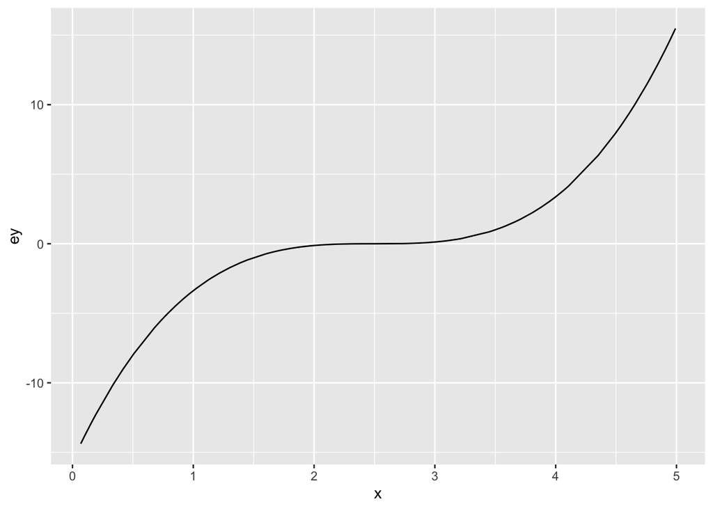

```r
ggplot(data = train_data) +
  geom_line(aes(y = ey, x = x))
```

Now, let’s define a function that runs regression with different levels of flexibilities using a generalized additive model from the `mgcv` package, predict $y$ for both the train and test datasets, and find train and test MSEs.

```r
est_gam <- function(k, train_data, test_data)
{

  # define train and test data
  train_data <- copy(train_data)
  test_data <- copy(test_data)

  #--- train a model ---#
  trained_model <- gam(y ~ s(x, k = k), sp = 0, data = train_data)

  #--- predict y for the train and test datasets ---#
  train_data[, y_hat := predict(trained_model, newdata = train_data)]
  train_data[, type := "Train"]
  test_data[, y_hat := predict(trained_model, newdata = test_data)]
  test_data[, type := "Test"]

  #--- combine before returning ---#
  return_data <-
    rbind(train_data, test_data) %>%
    .[, num_knots := k]

  return(return_data)
}
```

We now loop over the number of knots (`num_knots`).

```r
sim_results <-
  lapply(1:50, function(x) est_gam(x, train_data, test_data)) %>%
  rbindlist()
```

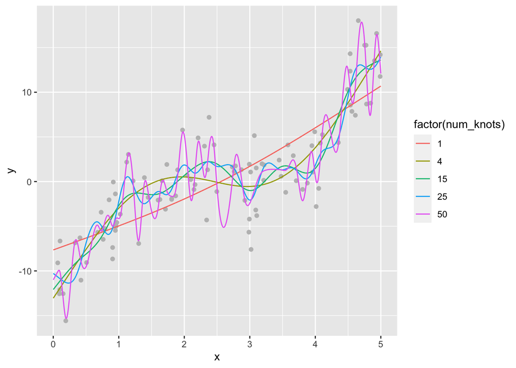

Figure 1: Fitted curves by gam() with different numbers of knots

```r
ggplot(sim_results[num_knots  %in% c(1, 4, 15, 25, 50), ]) +
  geom_point(data = train_data, aes(y = y, x = x), color = "grey") +
  geom_line(aes(y = y_hat, x = x, color = factor(num_knots)))
```

When the number of knots is $1$, gam is not flexible enough to capture the underlying cubic function. However, once the number of knots becomes $4$, it is capable of capturing the underlying cubic curve. However, when you increase the number of knots to 15, you see that the fitted curve is very wiggly (sudden and large changes in $y$ when $x$ is changed slighly). When `num_knots` $= 50$, the fitted curve looks crazy and does not resemble the underlying smooth cubic curve.

Now, let’s check how train and test MSEs change as k changes. As you can see in Figure 2 below, train MSE goes down as k increases (the more complex the model is, the better fit you will get for the train data). However, test MSE is the lowest when `num_knots` $= 4$, and it goes up afterward instead of going down. As we saw earlier, when model is made too flexible, it is trained to fit the trained data too well and lose generalizability (predict well for the dataset that has not been seen). This phenomenon is called over-fitting.

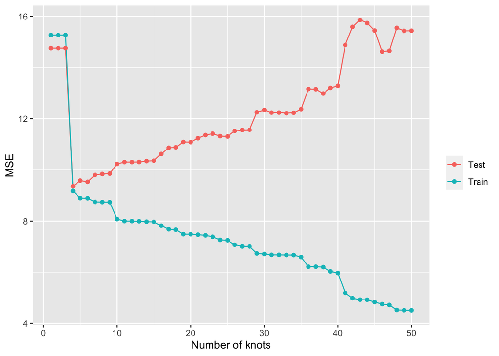

Figure 2: Train and test MSEs as a function of the number of knots

```r
#--- get train and test MSEs by k ---#
summary <-
  sim_results[, .(mse = mean((y_hat - y)^2)), by = .(num_knots, type)]

ggplot(summary) +
  geom_line(aes(y = mse, x = num_knots, color = type)) +
  geom_point(aes(y = mse, x = num_knots, color = type)) +
  xlab("Number of knots") +
  ylab("MSE") +
  scale_color_discrete(name = "")
```

This clearly tells us that we should NOT use training MSE to pick the best model.

# Variance-bias trade-off

Expected test MSE at $x = x_0$ can be written in general (no matter what the trained model is) as follows:

$$E[(y_0 - \hat{f}(x_0))^2] = Var(\hat{f}(x_0)) + E[y - \hat{f}(x_0)]^2 + Var(\mu)$$

The first term is the variance of predicted value at $x_0$, the second term is the squared bias of $\hat{f}(x_0)$ (how much $\hat{f}(x_0)$ differs from $E[y_0]$ on average), and $Var(\mu)$ is the variance of the error term.

To illustrate this trade-off, we will run Monte Carlo simulations. We repeat the folowing steps 500 times.

- step 1: generate train and test datasets
- step 2: train gam with different values of $k$ $(1, 5, 15, 25, 50)$ using the train dataset
- step 3: predict $y$ using the test dataset

Once all the iterations are completed, simulation results are summarized to estimate $Var(\hat{f}(x_0))$ and $E[y - \hat{f}(x_0)]^2$ for all the values of $x_0$ (all the $x$ values observed in the test dataset) by $k$. We then average them to find the overall $Var(\hat{f}(x_0))$ and $E[y - \hat{f}(x_0)]^2$ by $k$.

```r
x_train <- runif(100) * 5
# x_test is fixed to make it easier to get average conditonal on a given value of x later
x_test <- runif(100) * 5

# function that performs steps 1 ~ 3 (a single iteration)
run_mc <- function(i, x_train, x_test)
{
  print(i) # track progress
  train_data <- gen_data(x_train) # generate data
  test_data <- gen_data(x_test) # generate data
  # run gam for K = 1, ..., 50
  sim_results <-
    lapply(
      c(1, 5, 15, 25, 50),
      function(x) est_gam(x, train_data, test_data)
    ) %>%
    rbindlist()

  return(sim_results)
}

# runs run_mc 500 times
mc_results <-
  mclapply(
    1:500,
    function(x) run_mc(x, x_train, x_test),
    mc.cores = 12
  ) %>%
  rbindlist(idcol = "sim_id")
```

Figure 3 shows plots fitted curves for all the 500 simulations by $k$ (grey lines). The blue line is the true $E[y|x]$. The red line is $E[\hat{f}(x)]$[^1]. Figure Figure 4 plots the average[^2] $Var(\hat{f}(x))$ (red), $E[y - \hat{f}(x)]^2$ (blue), and MSE (darkgreen) from the test datasets for different values of $k$.

According to MSE presented in Figure 4, $k = 5$ is the best model among all the models tried in this experiment. In this experiment, we had test datasets available. However, in practice, we need to pick the best model when test datasets are not available most of the time. For such a case, we would like a clever way to estimate *test* MSE even when test datasets are not available. We will later talk about cross-validation as a means to do so.

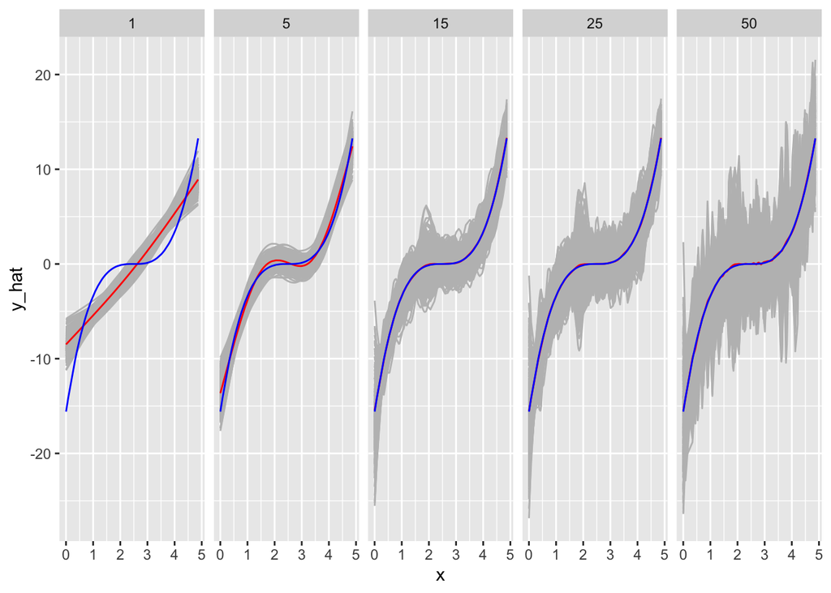

Figure 3: Bias-variance trade-off of GAM models with differing number of knots

```r
mc_results_sum <-
    mc_results %>%
    .[type == "Test", ] %>%
    .[, .(mean_y_hat = mean(y_hat)), by = .(x, ey, num_knots)]

ggplot() +
    geom_line(data = mc_results[type == "Test", ], aes(y = y_hat, x = x, group = sim_id), color = "gray") +
    geom_line(data = mc_results_sum, aes(y = mean_y_hat, x = x), color = "red") +
    geom_line(data = mc_results_sum, aes(y = ey, x= x), color = "blue") +
    facet_wrap(. ~ num_knots, ncol = 5)
```

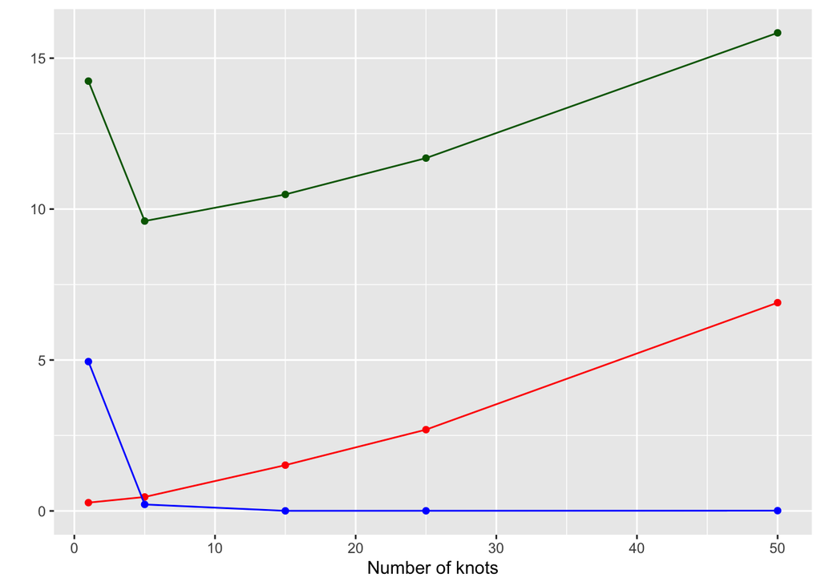

Figure 4: Expected variance of predicted values and bias

```r
sum_stat <-
  mc_results %>%
  .[type == "Test", ] %>%
  .[
    ,
    .(
      var_hat = var(y_hat), # varianc of y_hat
      bias_sq = mean(y_hat - ey)^2, # squared bias
      mse = mean((y - y_hat)^2)
    ),
    by = .(x, num_knots)
  ] %>%
  .[
    ,
    .(
      mean_var_hat = mean(var_hat),
      mean_bias_sq = mean(bias_sq),
      mean_mse = mean(mse)
    ),
    by = .(num_knots)
  ]

ggplot(data = sum_stat) +
  geom_line(aes(y = mean_var_hat, x = num_knots), color = "red") +
  geom_point(aes(y = mean_var_hat, x = num_knots), color = "red") +
  geom_line(aes(y = mean_bias_sq, x = num_knots), color = "blue") +
  geom_point(aes(y = mean_bias_sq, x = num_knots), color = "blue") +
  geom_line(aes(y = mean_mse, x = num_knots), color = "darkgreen") +
  geom_point(aes(y = mean_mse, x = num_knots), color = "darkgreen") +
  ylab("") +
  xlab("Number of knots")
```

# Additional Example (K-nearest neighbor regression)

```r
fit_knn <- function(k, train_data, test_data)
{

  # define train and test data
  train_data <- copy(train_data)
  test_data <- copy(test_data)

  #--- train a model ---#
  trained_model <- knnreg(y ~ x, k = k, data = train_data)

  #--- predict y for the train and test datasets ---#
  train_data[, y_hat := predict(trained_model, newdata = train_data)]
  train_data[, type := "Train"]
  test_data[, y_hat := predict(trained_model, newdata = test_data)]
  test_data[, type := "Test"]

  #--- combine before returning ---#
  return_data <-
    rbind(train_data, test_data) %>%
    .[, num_nbs := k]

  return(return_data)
}
```

We now loop over the number of neighbors (`k`).

```r
## generate train data
train_data <- gen_data(x = runif(1000) * 5)

## generate test data
test_data <- gen_data(x = runif(1000) * 5)

sim_results <-
  lapply(1:50, function(x) fit_knn(x, train_data, test_data)) %>%
  rbindlist()
```

Figure 5 presents the fitted regression lines for $k = 1, 5, 15, 25$, and $50$ using `knnreg()`, along with the observed data points in the train dataset.

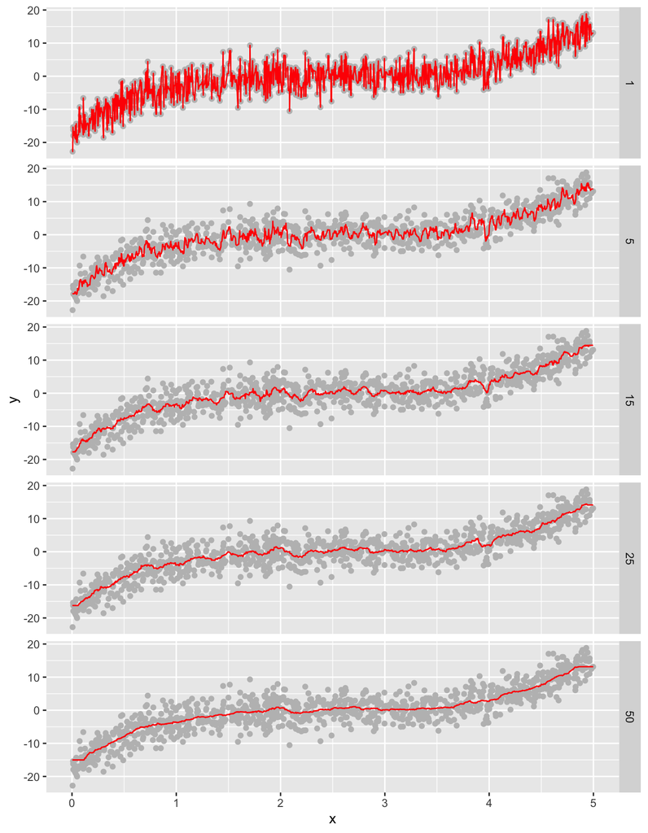

Figure 5: Fitted curves by knnreg() with different numbers of neighbors

```r
ggplot(sim_results[num_nbs  %in% c(1, 5, 15, 25, 50), ]) +
  geom_point(data = train_data, aes(y = y, x = x), color = "gray") +
  geom_line(aes(y = y_hat, x = x), color = "red") +
  facet_grid(num_nbs ~ .)
```

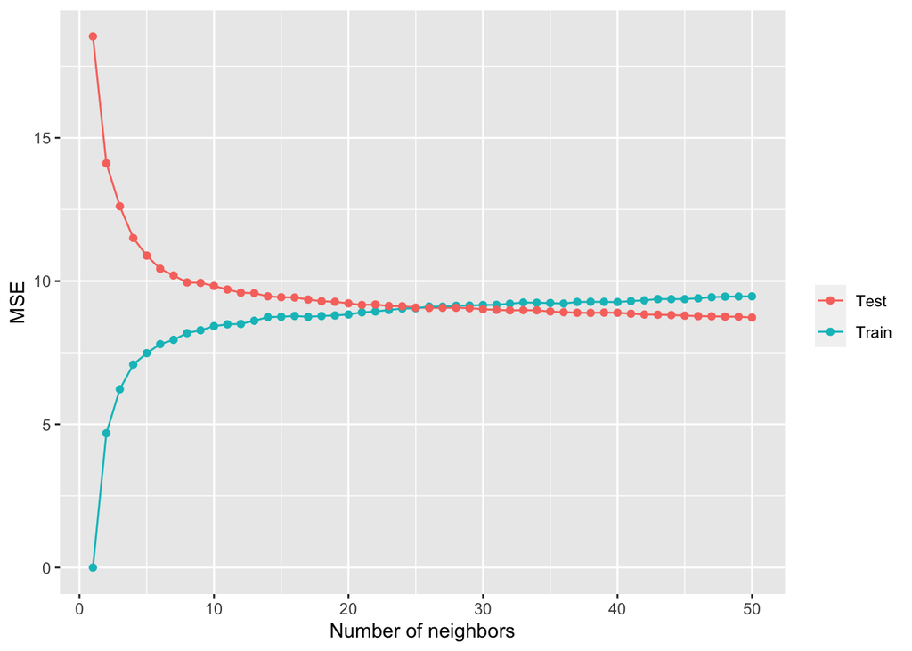

```r
#--- get train and test MSEs by k ---#
summary <-
  sim_results[, .(mse = mean((y_hat - y)^2)), by = .(num_nbs, type)]

ggplot(summary) +
  geom_line(aes(y = mse, x = num_nbs, color = type)) +
  geom_point(aes(y = mse, x = num_nbs, color = type)) +
  xlab("Number of neighbors") +
  ylab("MSE") +
  scale_color_discrete(name = "")
```

## Footnotes

[^1]: This figure is a collection of individual fitted curve just like the ones shown in Figure 1.
[^2]: averaged over $x$, and then averaged over iterations